# Neuroconductor: A Neuroimaging Analysis Project in R

September 19, 2016

## Stroke Segmentation in CT Scans

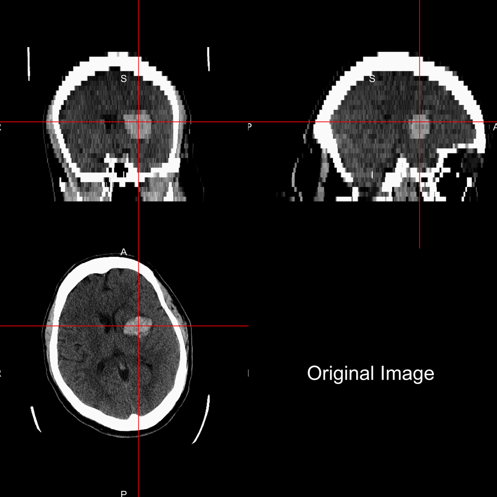

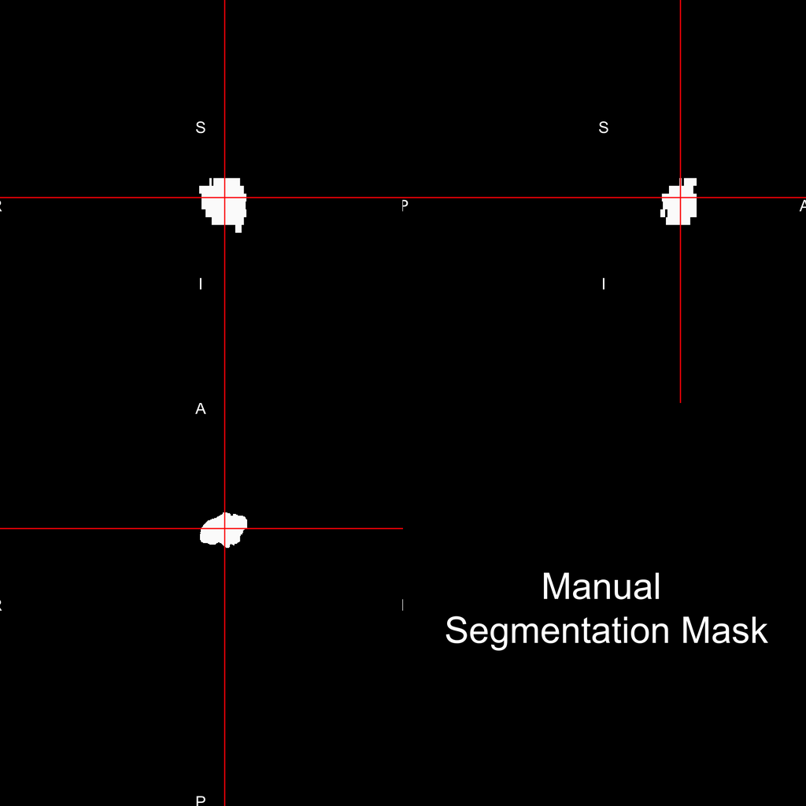

## Shiny Application

[figure not shown]

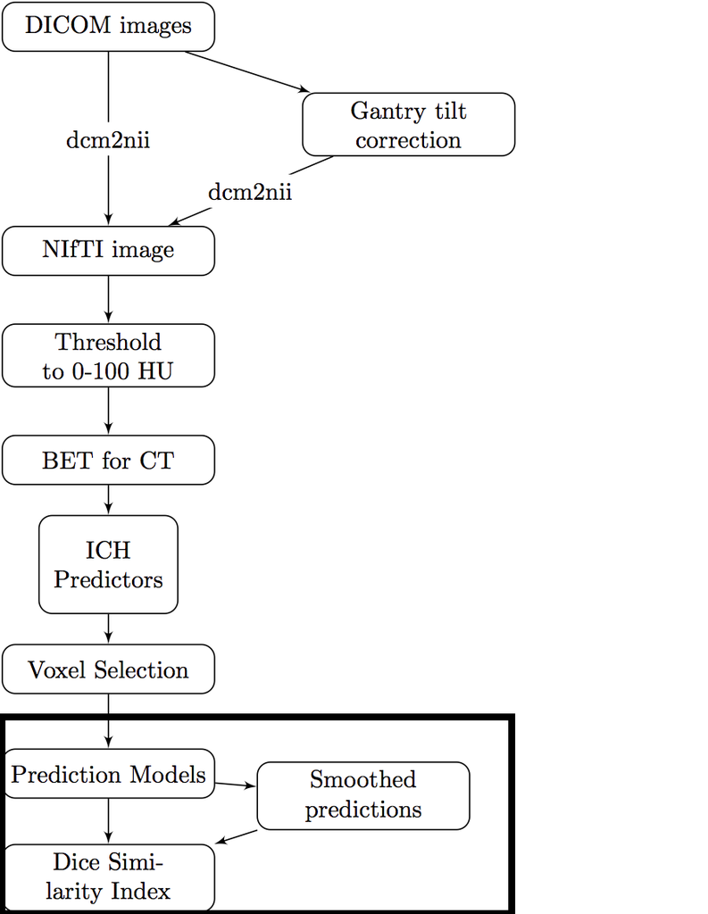

[figure not shown]

## (A Lot of) Software Choices for fMRI Analysis

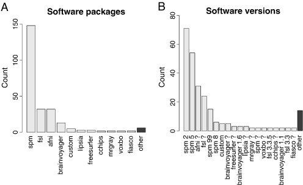

From Carp, Joshua. "The secret lives of experiments: methods reporting in the fMRI literature." Neuroimage 63.1 (2012): 289-300.

## Number of Downloads (My CRAN packages)

From the `cranlogs` R package:

| Package | All Time | Last Week |
| --- | --- | --- |
| fslr | 8549 | 121 |
| brainR | 8638 | 38 |
| freesurfer | 49 | 36 |
| matlabr | 2970 | 33 |
| papayar | 517 | 33 |
| WhiteStripe | 4755 | 19 |
| spm12r | 1641 | 18 |
| oasis | 1307 | 15 |

## R Package Interfaces with Imaging Software

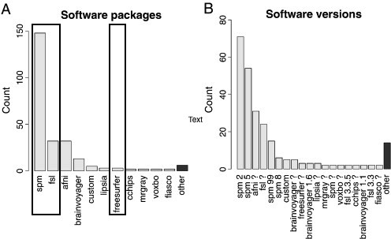

## Neuroconductor: A Neuroimaging R Repository Hosted on GitHub and Checked by Travis CI

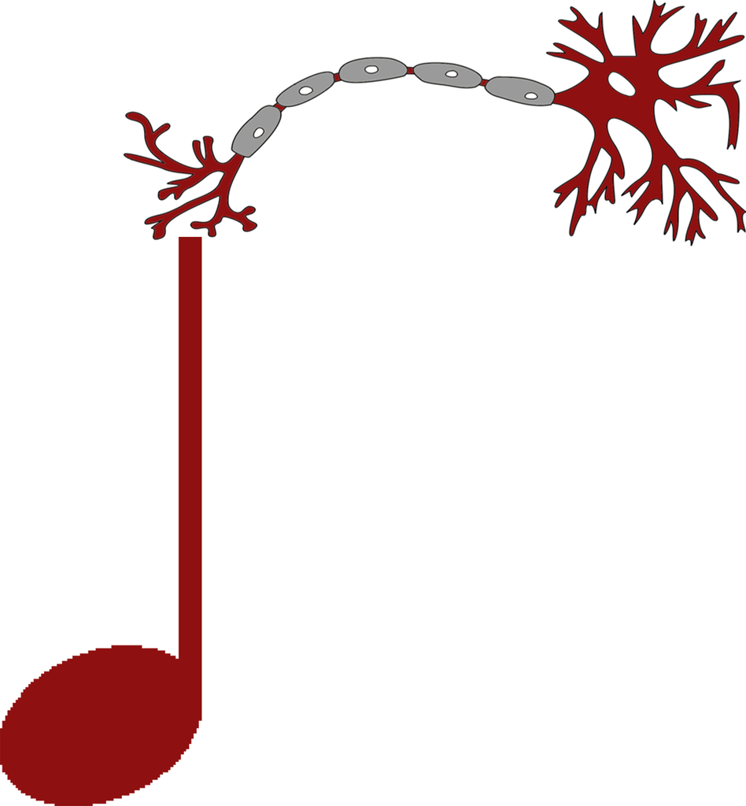

[figure not shown]

## Neuroconductor Goals (Similar to BioC)

1. Lower the bar to entry - just have to know R
   - more packages to **interface** with other programs
2. All the things a repository has (checks/rules/**stability**)
   - additional checks with imaging software installed (e.g. examples)
3. **Data** packages to test packages with real data (images can be big)
4. Detailed **vignettes/tutorials** on how to actually perform an analysis
5. Image analyses use all the "things R has to offer" (packaging system/**reproducibility**/etc.)

## Under Development R Packages

1. nitrc - download data from the **NITRC repository**
2. MNITemplate\(^*\) - data of a population-level "template" image
3. EveTemplate\(^*\) - data of a different template image
4. kirby21 - data package with 2 subjects, 2 visits with multimodal imaging
5. rcamino - interface to analyze DTI data
6. msseg - MS lesion segmentation
7. extrantsr - pipelines for structural imaging analysis

Not started yet

\(^*\) - working with Jean-Philippe Fortin on these

## Neuroconductor

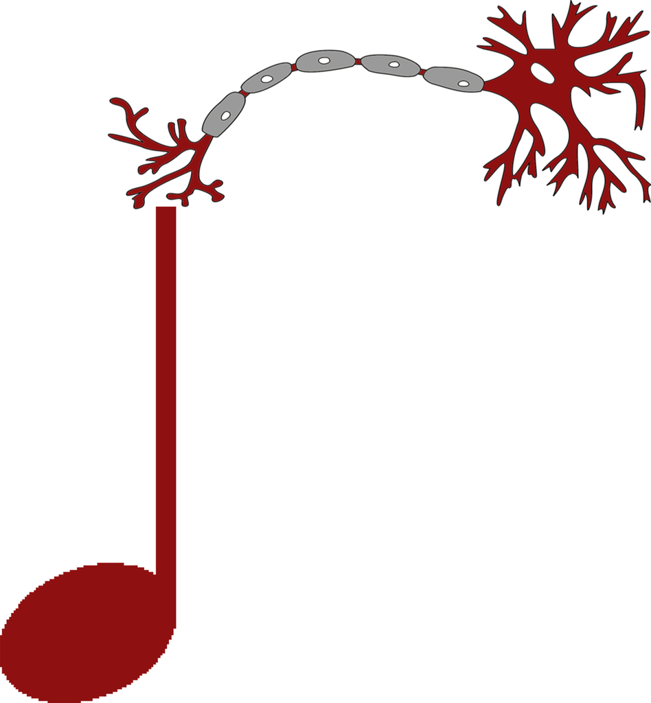

Hopeful Solutions

1. Help improve reproducibility in imaging
2. Standardize the syntax / R objects for imaging a bit (I'm realistic)
3. Easily-accessible content

Problems

1. More control over the workflow = more work (**for us**!)
2. Users need external software (versions/installation)
3. No control over external software
4. Need the content (buy-in from the community)

## Thanks

## Current R Capabilities in Imaging

1. **Image I/O**
2. **Plotting**
3. Image registration (linear/non-linear)
4. **Image smoothing**
5. **Tissue-class segmentation (white/gray/CSF)**
6. Inhomogeneity correction
7. **Intensity normalization**
8. Temporal filtering
9. Large linear models
10. Analysis of fMRI task data
11. Diffusion tensor models